# Notebook

### PART 1. Data Loading and Inspection

```python
import pandas as pd
import seaborn as sns
import numpy as np
import matplotlib.pyplot as plt
import statsmodels.api as sm
from scipy import stats
```

```python
Obesity = pd.read_csv('Data_Obesity..csv')
Obesity
```

|  | Sex | Age | Height | Overweight_Obese_Family | Consumption_of_Fast_Food | Frequency_of_Consuming_Vegetables | Number_of_Main_Meals_Daily | Food_Intake_Between_Meals | Smoking | Liquid_Intake_Daily | Calculation_of_Calorie_Intake | Physical_Excercise | Schedule_Dedicated_to_Technology | Type_of_Transportation_Used | Class |
| --- | --- | --- | --- | --- | --- | --- | --- | --- | --- | --- | --- | --- | --- | --- | --- |
| 0 | 2 | 18 | 155 | 2 | 2 | 3 | 1 | 3 | 2 | 1 | 2 | 3 | 3 | 4 | 2 |
| 1 | 2 | 18 | 158 | 2 | 2 | 3 | 1 | 1 | 2 | 1 | 2 | 1 | 3 | 3 | 2 |
| 2 | 2 | 18 | 159 | 2 | 2 | 2 | 1 | 3 | 2 | 3 | 2 | 2 | 3 | 4 | 2 |
| 3 | 2 | 18 | 162 | 2 | 2 | 2 | 2 | 2 | 2 | 2 | 2 | 1 | 3 | 4 | 2 |
| 4 | 2 | 18 | 165 | 2 | 1 | 2 | 1 | 3 | 2 | 1 | 2 | 3 | 3 | 2 | 2 |
| ... | ... | ... | ... | ... | ... | ... | ... | ... | ... | ... | ... | ... | ... | ... | ... |
| 1605 | 2 | 51 | 165 | 2 | 1 | 1 | 3 | 4 | 1 | 3 | 1 | 3 | 1 | 1 | 4 |
| 1606 | 2 | 51 | 163 | 2 | 1 | 2 | 2 | 4 | 2 | 2 | 2 | 5 | 1 | 1 | 4 |
| 1607 | 2 | 52 | 162 | 1 | 2 | 1 | 3 | 4 | 1 | 3 | 1 | 4 | 1 | 1 | 4 |
| 1608 | 2 | 53 | 168 | 2 | 1 | 1 | 3 | 4 | 1 | 2 | 2 | 2 | 1 | 1 | 4 |
| 1609 | 2 | 54 | 170 | 1 | 1 | 1 | 3 | 4 | 1 | 3 | 2 | 4 | 3 | 1 | 4 |

1610 rows Ã— 15 columns

```python
Obesity.describe()
```

|  | Sex | Age | Height | Overweight_Obese_Family | Consumption_of_Fast_Food | Frequency_of_Consuming_Vegetables | Number_of_Main_Meals_Daily | Food_Intake_Between_Meals | Smoking | Liquid_Intake_Daily | Calculation_of_Calorie_Intake | Physical_Excercise | Schedule_Dedicated_to_Technology | Type_of_Transportation_Used | Class |
| --- | --- | --- | --- | --- | --- | --- | --- | --- | --- | --- | --- | --- | --- | --- | --- |
| count | 1610.000000 | 1610.000000 | 1610.000000 | 1610.000000 | 1610.000000 | 1610.000000 | 1610.000000 | 1610.000000 | 1610.00000 | 1610.000000 | 1610.000000 | 1610.000000 | 1610.000000 | 1610.000000 | 1610.000000 |
| mean | 1.557764 | 33.115528 | 167.741615 | 1.834783 | 1.729193 | 2.063354 | 1.872050 | 2.395652 | 1.69441 | 2.108696 | 1.822360 | 3.265839 | 2.012422 | 2.667081 | 2.678882 |
| std | 0.496806 | 9.835076 | 7.979873 | 0.371492 | 0.444515 | 0.746043 | 0.638345 | 1.010501 | 0.46080 | 0.814710 | 0.382328 | 1.343035 | 0.697929 | 1.518388 | 0.815855 |
| min | 1.000000 | 18.000000 | 150.000000 | 1.000000 | 1.000000 | 1.000000 | 1.000000 | 1.000000 | 1.00000 | 1.000000 | 1.000000 | 1.000000 | 1.000000 | 1.000000 | 1.000000 |
| 25% | 1.000000 | 25.000000 | 161.000000 | 2.000000 | 1.000000 | 2.000000 | 1.000000 | 2.000000 | 1.00000 | 1.000000 | 2.000000 | 2.000000 | 2.000000 | 1.000000 | 2.000000 |
| 50% | 2.000000 | 32.000000 | 168.000000 | 2.000000 | 2.000000 | 2.000000 | 2.000000 | 2.000000 | 2.00000 | 2.000000 | 2.000000 | 3.000000 | 2.000000 | 3.000000 | 3.000000 |
| 75% | 2.000000 | 41.000000 | 174.000000 | 2.000000 | 2.000000 | 3.000000 | 2.000000 | 3.000000 | 2.00000 | 3.000000 | 2.000000 | 4.000000 | 2.000000 | 4.000000 | 3.000000 |
| max | 2.000000 | 54.000000 | 193.000000 | 2.000000 | 2.000000 | 3.000000 | 3.000000 | 4.000000 | 2.00000 | 3.000000 | 2.000000 | 5.000000 | 3.000000 | 5.000000 | 4.000000 |

```python
Obesity.info()
```

```
<class 'pandas.core.frame.DataFrame'>
RangeIndex: 1610 entries, 0 to 1609
Data columns (total 15 columns):
 #   Column                             Non-Null Count  Dtype
---  ------                             --------------  -----
 0   Sex                                1610 non-null   int64
 1   Age                                1610 non-null   int64
 2   Height                             1610 non-null   int64
 3   Overweight_Obese_Family            1610 non-null   int64
 4   Consumption_of_Fast_Food           1610 non-null   int64
 5   Frequency_of_Consuming_Vegetables  1610 non-null   int64
 6   Number_of_Main_Meals_Daily         1610 non-null   int64
 7   Food_Intake_Between_Meals          1610 non-null   int64
 8   Smoking                            1610 non-null   int64
 9   Liquid_Intake_Daily                1610 non-null   int64
 10  Calculation_of_Calorie_Intake      1610 non-null   int64
 11  Physical_Excercise                 1610 non-null   int64
 12  Schedule_Dedicated_to_Technology   1610 non-null   int64
 13  Type_of_Transportation_Used        1610 non-null   int64
 14  Class                              1610 non-null   int64
dtypes: int64(15)
memory usage: 188.8 KB
```

```python
Obesity.describe()
```

|  | Sex | Age | Height | Overweight_Obese_Family | Consumption_of_Fast_Food | Frequency_of_Consuming_Vegetables | Number_of_Main_Meals_Daily | Food_Intake_Between_Meals | Smoking | Liquid_Intake_Daily | Calculation_of_Calorie_Intake | Physical_Excercise | Schedule_Dedicated_to_Technology | Type_of_Transportation_Used | Class |
| --- | --- | --- | --- | --- | --- | --- | --- | --- | --- | --- | --- | --- | --- | --- | --- |
| count | 1610.000000 | 1610.000000 | 1610.000000 | 1610.000000 | 1610.000000 | 1610.000000 | 1610.000000 | 1610.000000 | 1610.00000 | 1610.000000 | 1610.000000 | 1610.000000 | 1610.000000 | 1610.000000 | 1610.000000 |
| mean | 1.557764 | 33.115528 | 167.741615 | 1.834783 | 1.729193 | 2.063354 | 1.872050 | 2.395652 | 1.69441 | 2.108696 | 1.822360 | 3.265839 | 2.012422 | 2.667081 | 2.678882 |
| std | 0.496806 | 9.835076 | 7.979873 | 0.371492 | 0.444515 | 0.746043 | 0.638345 | 1.010501 | 0.46080 | 0.814710 | 0.382328 | 1.343035 | 0.697929 | 1.518388 | 0.815855 |
| min | 1.000000 | 18.000000 | 150.000000 | 1.000000 | 1.000000 | 1.000000 | 1.000000 | 1.000000 | 1.00000 | 1.000000 | 1.000000 | 1.000000 | 1.000000 | 1.000000 | 1.000000 |
| 25% | 1.000000 | 25.000000 | 161.000000 | 2.000000 | 1.000000 | 2.000000 | 1.000000 | 2.000000 | 1.00000 | 1.000000 | 2.000000 | 2.000000 | 2.000000 | 1.000000 | 2.000000 |
| 50% | 2.000000 | 32.000000 | 168.000000 | 2.000000 | 2.000000 | 2.000000 | 2.000000 | 2.000000 | 2.00000 | 2.000000 | 2.000000 | 3.000000 | 2.000000 | 3.000000 | 3.000000 |
| 75% | 2.000000 | 41.000000 | 174.000000 | 2.000000 | 2.000000 | 3.000000 | 2.000000 | 3.000000 | 2.00000 | 3.000000 | 2.000000 | 4.000000 | 2.000000 | 4.000000 | 3.000000 |
| max | 2.000000 | 54.000000 | 193.000000 | 2.000000 | 2.000000 | 3.000000 | 3.000000 | 4.000000 | 2.00000 | 3.000000 | 2.000000 | 5.000000 | 3.000000 | 5.000000 | 4.000000 |

```python
print(Obesity.describe())
```

```
               Sex          Age       Height  Overweight_Obese_Family  \
count  1610.000000  1610.000000  1610.000000              1610.000000
mean      1.557764    33.115528   167.741615                 1.834783
std       0.496806     9.835076     7.979873                 0.371492
min       1.000000    18.000000   150.000000                 1.000000
25%       1.000000    25.000000   161.000000                 2.000000
50%       2.000000    32.000000   168.000000                 2.000000
75%       2.000000    41.000000   174.000000                 2.000000
max       2.000000    54.000000   193.000000                 2.000000

       Consumption_of_Fast_Food  Frequency_of_Consuming_Vegetables  \
count               1610.000000                        1610.000000
mean                   1.729193                           2.063354
std                    0.444515                           0.746043
min                    1.000000                           1.000000
25%                    1.000000                           2.000000
50%                    2.000000                           2.000000
75%                    2.000000                           3.000000
max                    2.000000                           3.000000

       Number_of_Main_Meals_Daily  Food_Intake_Between_Meals     Smoking  \
count                 1610.000000                1610.000000  1610.00000
mean                     1.872050                   2.395652     1.69441
std                      0.638345                   1.010501     0.46080
min                      1.000000                   1.000000     1.00000
25%                      1.000000                   2.000000     1.00000
50%                      2.000000                   2.000000     2.00000
75%                      2.000000                   3.000000     2.00000
max                      3.000000                   4.000000     2.00000

       Liquid_Intake_Daily  Calculation_of_Calorie_Intake  Physical_Excercise  \
count          1610.000000                    1610.000000         1610.000000
mean              2.108696                       1.822360            3.265839
std               0.814710                       0.382328            1.343035
min               1.000000                       1.000000            1.000000
25%               1.000000                       2.000000            2.000000
50%               2.000000                       2.000000            3.000000
75%               3.000000                       2.000000            4.000000
max               3.000000                       2.000000            5.000000

       Schedule_Dedicated_to_Technology  Type_of_Transportation_Used  \
count                       1610.000000                  1610.000000
mean                           2.012422                     2.667081
std                            0.697929                     1.518388
min                            1.000000                     1.000000
25%                            2.000000                     1.000000
50%                            2.000000                     3.000000
75%                            2.000000                     4.000000
max                            3.000000                     5.000000

             Class
count  1610.000000
mean      2.678882
std       0.815855
min       1.000000
25%       2.000000
50%       3.000000
75%       3.000000
max       4.000000
```

```python
# Inspect the structure of the data
num_rows, num_cols = Obesity.shape
data_types = Obesity.dtypes
missing_values = Obesity.isnull().sum()

# Output the results
print(f"Number of rows: {num_rows}, Number of columns: {num_cols}")
print("Data types of columns:")
print(data_types)
print("Missing values in each column:")
print(missing_values)
```

```
Number of rows: 1610, Number of columns: 15
Data types of columns:
Sex                                  int64
Age                                  int64
Height                               int64
Overweight_Obese_Family              int64
Consumption_of_Fast_Food             int64
Frequency_of_Consuming_Vegetables    int64
Number_of_Main_Meals_Daily           int64
Food_Intake_Between_Meals            int64
Smoking                              int64
Liquid_Intake_Daily                  int64
Calculation_of_Calorie_Intake        int64
Physical_Excercise                   int64
Schedule_Dedicated_to_Technology     int64
Type_of_Transportation_Used          int64
Class                                int64
dtype: object
Missing values in each column:
Sex                                  0
Age                                  0
Height                               0
Overweight_Obese_Family              0
Consumption_of_Fast_Food             0
Frequency_of_Consuming_Vegetables    0
Number_of_Main_Meals_Daily           0
Food_Intake_Between_Meals            0
Smoking                              0
Liquid_Intake_Daily                  0
Calculation_of_Calorie_Intake        0
Physical_Excercise                   0
Schedule_Dedicated_to_Technology     0
Type_of_Transportation_Used          0
Class                                0
dtype: int64
```

### PART 2.DATA CLEANING (IF NECESSARY)

```python
# Checking for duplicate rows
duplicates = Obesity.duplicated().sum()
if duplicates > 0:
    Obesity.drop_duplicates(inplace=True)

# Ensure all numeric columns are in the correct data type
numeric_columns = Obesity.select_dtypes(include=['float64', 'int64']).columns
Obesity[numeric_columns] = Obesity[numeric_columns].apply(pd.to_numeric, errors='coerce')

Obesity
```

|  | Sex | Age | Height | Overweight_Obese_Family | Consumption_of_Fast_Food | Frequency_of_Consuming_Vegetables | Number_of_Main_Meals_Daily | Food_Intake_Between_Meals | Smoking | Liquid_Intake_Daily | Calculation_of_Calorie_Intake | Physical_Excercise | Schedule_Dedicated_to_Technology | Type_of_Transportation_Used | Class |
| --- | --- | --- | --- | --- | --- | --- | --- | --- | --- | --- | --- | --- | --- | --- | --- |
| 0 | 2 | 18 | 155 | 2 | 2 | 3 | 1 | 3 | 2 | 1 | 2 | 3 | 3 | 4 | 2 |
| 1 | 2 | 18 | 158 | 2 | 2 | 3 | 1 | 1 | 2 | 1 | 2 | 1 | 3 | 3 | 2 |
| 2 | 2 | 18 | 159 | 2 | 2 | 2 | 1 | 3 | 2 | 3 | 2 | 2 | 3 | 4 | 2 |
| 3 | 2 | 18 | 162 | 2 | 2 | 2 | 2 | 2 | 2 | 2 | 2 | 1 | 3 | 4 | 2 |
| 4 | 2 | 18 | 165 | 2 | 1 | 2 | 1 | 3 | 2 | 1 | 2 | 3 | 3 | 2 | 2 |
| ... | ... | ... | ... | ... | ... | ... | ... | ... | ... | ... | ... | ... | ... | ... | ... |
| 1605 | 2 | 51 | 165 | 2 | 1 | 1 | 3 | 4 | 1 | 3 | 1 | 3 | 1 | 1 | 4 |
| 1606 | 2 | 51 | 163 | 2 | 1 | 2 | 2 | 4 | 2 | 2 | 2 | 5 | 1 | 1 | 4 |
| 1607 | 2 | 52 | 162 | 1 | 2 | 1 | 3 | 4 | 1 | 3 | 1 | 4 | 1 | 1 | 4 |
| 1608 | 2 | 53 | 168 | 2 | 1 | 1 | 3 | 4 | 1 | 2 | 2 | 2 | 1 | 1 | 4 |
| 1609 | 2 | 54 | 170 | 1 | 1 | 1 | 3 | 4 | 1 | 3 | 2 | 4 | 3 | 1 | 4 |

1610 rows Ã— 15 columns

### PART 3. Data Visualisation

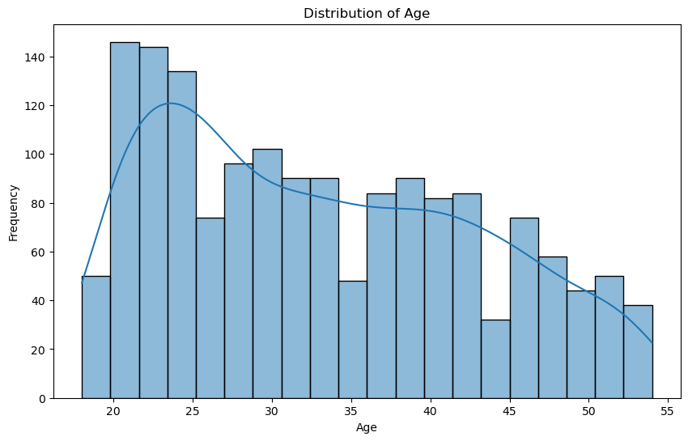

```python
# Histogram of Age
plt.figure(figsize=(10, 6))
sns.histplot(Obesity['Age'], bins=20, kde=True)
plt.title('Distribution of Age')
plt.xlabel('Age')
plt.ylabel('Frequency')
plt.show()
```

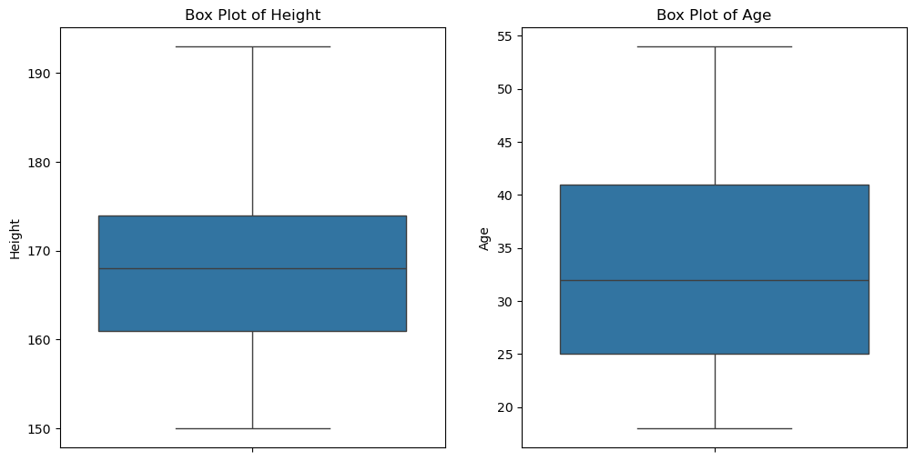

```python
# Box plots for Height and Age
plt.figure(figsize=(12, 6))
plt.subplot(1, 2, 1)
sns.boxplot(y=Obesity['Height'])
plt.title('Box Plot of Height')

plt.subplot(1, 2, 2)
sns.boxplot(y=Obesity['Age'])
plt.title('Box Plot of Age')
plt.show()
```

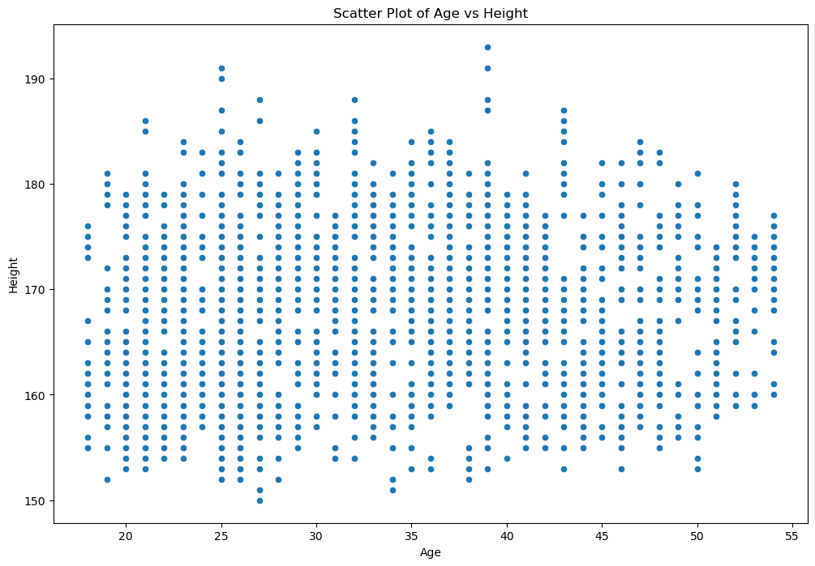

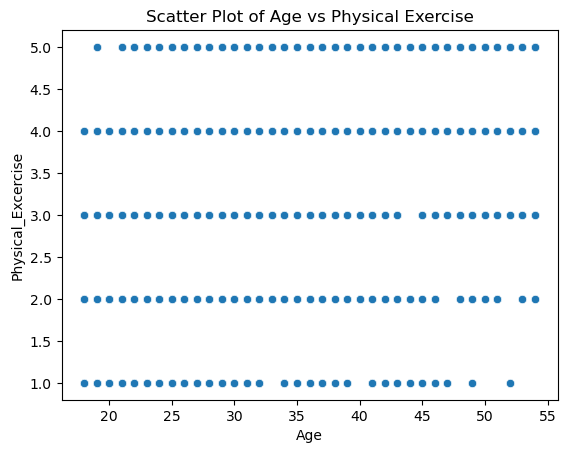

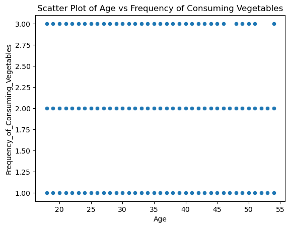

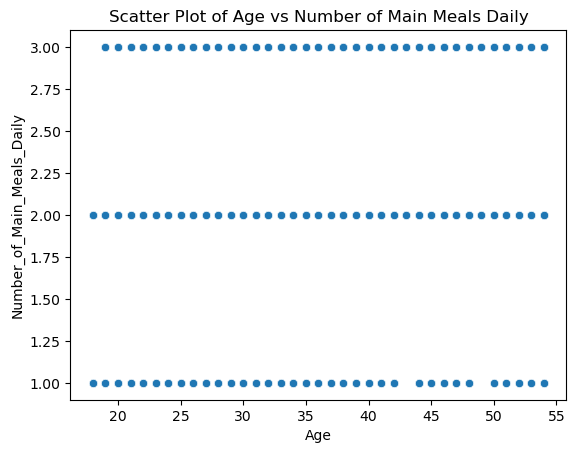

```python
# Scatterplots for Age vs. other variables
plt.figure(figsize=(12, 8))
sns.scatterplot(x='Age', y='Height', data=Obesity)
plt.title('Scatter Plot of Age vs Height')
plt.show()

sns.scatterplot(x='Age', y='Physical_Excercise', data=Obesity)
plt.title('Scatter Plot of Age vs Physical Exercise')
plt.show()

sns.scatterplot(x='Age', y='Frequency_of_Consuming_Vegetables', data=Obesity)
plt.title('Scatter Plot of Age vs Frequency of Consuming Vegetables')
plt.show()

sns.scatterplot(x='Age', y='Number_of_Main_Meals_Daily', data=Obesity)
plt.title('Scatter Plot of Age vs Number of Main Meals Daily')
plt.show()
```

### PART 4. Correlation Analysis

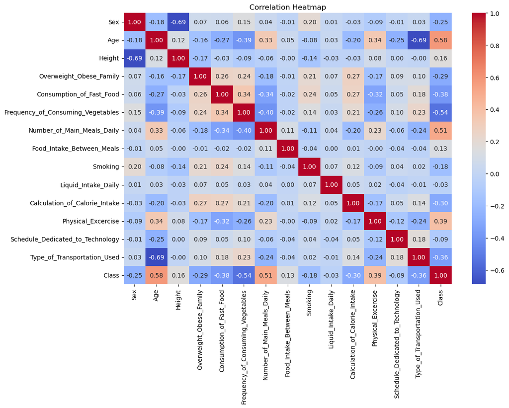

```python
correlation_matrix = Obesity.corr()

# heatmap
plt.figure(figsize=(12, 8))
sns.heatmap(correlation_matrix, annot=True, fmt=".2f", cmap='coolwarm')
plt.title('Correlation Heatmap')
plt.show()
```

### Simple Linear Regression

```python
X = Obesity['Age']
y = Obesity['Height']

X = sm.add_constant(X)
model = sm.OLS(y, X).fit()

print(model.summary())
```

```
                            OLS Regression Results
==============================================================================
Dep. Variable:                 Height   R-squared:                       0.013
Model:                            OLS   Adj. R-squared:                  0.013
Method:                 Least Squares   F-statistic:                     21.74
Date:                Wed, 09 Oct 2024   Prob (F-statistic):           3.38e-06
Time:                        10:12:33   Log-Likelihood:                -5617.0
No. Observations:                1610   AIC:                         1.124e+04
Df Residuals:                    1608   BIC:                         1.125e+04
Df Model:                           1
Covariance Type:            nonrobust
==============================================================================
                 coef    std err          t      P>|t|      [0.025      0.975]
------------------------------------------------------------------------------
const        164.6385      0.694    237.135      0.000     163.277     166.000
Age            0.0937      0.020      4.662      0.000       0.054       0.133
==============================================================================
Omnibus:                       87.466   Durbin-Watson:                   0.691
Prob(Omnibus):                  0.000   Jarque-Bera (JB):               41.915
Skew:                           0.197   Prob(JB):                     7.91e-10
Kurtosis:                       2.315   Cond. No.                         121.
==============================================================================

Notes:
[1] Standard Errors assume that the covariance matrix of the errors is correctly specified.
```

Coefficient for Age: With the coefficient for Age at 0.0937. It indicates that for each additional year of age, the height is expected to increase by approximately 0.0937 cm. This suggests a positive relationship between age and height; as individuals get older, they tend to be slightly taller.

Statistical Significance: The p-value for Age is 0.000, which is significantly less than the common threshold of 0.05. This implies that the relationship between age and height is statistically significant. Therefore, age is a meaningful predictor of height in this model.

R-squared Value: The R-squared value is 0.013. This means that only 1.3% of the variance in height is explained by age. It is quite low, suggesting that while age has a statistically significant effect on height, it explains only a small portion of the variability in height. Other factors likely to play a much larger role.

F-statistic: The F-statistic is 21.74, with a corresponding p-value of 3.38e-06. This indicates that the model as a whole is statistically significant, meaning that at least one predictor variable (in this case, age) significantly predicts the dependent variable (height).

### PART 6. Multiple Linear Regression

```python
X_multiple = Obesity[['Age', 'Height', 'Frequency_of_Consuming_Vegetables',
                  'Number_of_Main_Meals_Daily', 'Liquid_Intake_Daily',
                  'Physical_Excercise', 'Schedule_Dedicated_to_Technology']]
y_multiple = Obesity['Overweight_Obese_Family']

X_multiple = sm.add_constant(X_multiple)
model_multiple = sm.OLS(y_multiple, X_multiple).fit()

print(model_multiple.summary())
```

```
                               OLS Regression Results
===================================================================================
Dep. Variable:     Overweight_Obese_Family   R-squared:                       0.108
Model:                                 OLS   Adj. R-squared:                  0.104
Method:                      Least Squares   F-statistic:                     27.68
Date:                     Wed, 09 Oct 2024   Prob (F-statistic):           4.08e-36
Time:                             10:37:37   Log-Likelihood:                -597.80
No. Observations:                     1610   AIC:                             1212.
Df Residuals:                         1602   BIC:                             1255.
Df Model:                                7
Covariance Type:                 nonrobust
=====================================================================================================
                                        coef    std err          t      P>|t|      [0.025      0.975]
-----------------------------------------------------------------------------------------------------
const                                 2.8965      0.201     14.378      0.000       2.501       3.292
Age                                  -0.0002      0.001     -0.208      0.835      -0.002       0.002
Height                               -0.0069      0.001     -6.191      0.000      -0.009      -0.005
Frequency_of_Consuming_Vegetables     0.0774      0.014      5.688      0.000       0.051       0.104
Number_of_Main_Meals_Daily           -0.0628      0.016     -4.052      0.000      -0.093      -0.032
Liquid_Intake_Daily                   0.0329      0.011      3.044      0.002       0.012       0.054
Physical_Excercise                   -0.0224      0.007     -3.181      0.001      -0.036      -0.009
Schedule_Dedicated_to_Technology      0.0338      0.013      2.596      0.010       0.008       0.059
==============================================================================
Omnibus:                      378.855   Durbin-Watson:                   1.978
Prob(Omnibus):                  0.000   Jarque-Bera (JB):              688.710
Skew:                          -1.518   Prob(JB):                    2.81e-150
Kurtosis:                       4.024   Cond. No.                     3.94e+03
==============================================================================

Notes:
[1] Standard Errors assume that the covariance matrix of the errors is correctly specified.
[2] The condition number is large, 3.94e+03. This might indicate that there are
strong multicollinearity or other numerical problems.
```

# PART 6. INTERPRETATION

R-squared Value: The R-squared value is 0.108, indicating that approximately 10.8% of the variance in Overweight_Obese_Family is explained by the predictors in the model. Therefore, while the model has some explanatory power, a significant portion of the variance remains unexplained.

#### Which predictors are statistically significant?

1. Constant (Intercept):

Coefficient: 2.8965, p-value: 0.000 Statistically significant; this represents the expected value of Overweight_Obese_Family when all other predictors are zero.

2. Height:

Coefficient: -0.0069, p-value: 0.000 Statistically significant; as height increases, the likelihood of being classified as overweight or obese decreases slightly.

3. Frequency of Consuming Vegetables:

Coefficient: 0.0774, p-value: 0.000 Statistically significant; it means a higher frequency of vegetable consumption is associated with a higher likelihood of being classified as overweight or obese.

4. Number of Main Meals Daily:

Coefficient: -0.0628, p-value: 0.000 Statistically significant; that is more main meals daily is associated with a lower likelihood of being classified as overweight or obese.

5. Liquid Intake Daily:

Coefficient: 0.0329, p-value: 0.002 Statistically significant; indicates that increased liquid intake is associated with a higher likelihood of being classified as overweight or obese.

6. Physical Exercise:

Coefficient: -0.0224, p-value: 0.001 Statistically significant; more physical exercise is associated with a lower likelihood of being classified as overweight or obese.

7. Schedule Dedicated to Technology:

Coefficient: 0.0338, p-value: 0.010 Statistically significant; suggests that more time spent on technology is associated with a higher likelihood of being classified as overweight or obese.

### PART 7. CONCLUSION

#### Factors with the Strongest Relationships with Overweight_Obese_Family:

1. Height
2. Frequency of Consuming Vegetables
3. Number of Main Meals Daily
4. Liquid Intake Daily
5. Physical Exercise
6. Schedule Dedicated to Technology

#### How well do the simple and multiple linear regression models explain the variance in overweight_obese_family?

1. Simple Linear Regression (Age and Height): The R-squared value was 0.013, indicating that only 1.3% of the variance in height was explained by age. This suggests a weak relationship, with most of the variance attributed to other factors.
2. Multiple Linear Regression (Overweight_Obese_Family): The R-squared value was 0.108, meaning that approximately 10.8% of the variance in Overweight_Obese_Family is explained by the included predictors. While this is an improvement over the simple model, it still indicates that a significant portion of variance remains unexplained, suggesting that other factors not included in this model may play important roles.